# Lecture 411

2021-10-03

## Principal Component Analysis

## Recap

**Prev**: Comparing data

- 401 Lecture Introduction to Machine Learning
- 402 Lecture Artificial Neural Networks
- 403 Lecture Support vector machines
- 404 Practical session

**Now**: Principal Component Analysis

- Principal components
- `stats::prcomp`
- Dimensionality reduction

## Principal components

**Principal component** are

- a set of directions orthogonal to each other
- that best fit a set of data

Can be interpreted as a *“re-projection”* of the data

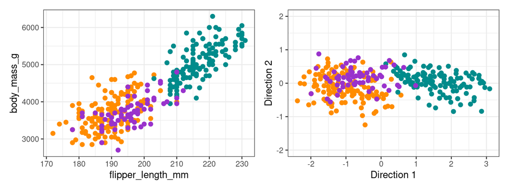

## Dimensionality reduction

Alternatively, principal components can be interpreted as

- **lower-dimensional** representation of the data

Especially useful when working numerous variables

- a limited number of principal components can be retained
  - most variance maintained
  - distance in data space approximated
  - high-dimensional data can be more easily plotted
- commonly used as dimensionality reduction step
  - supervised learning models
    - linear regression
  - clustering

## stats::prcomp

Principal component analysis on body mass, flipper length, and bill length and depth

```r
penguins_pca <-
  palmerpenguins::penguins %>%
  dplyr::select(bill_length_mm, bill_depth_mm, flipper_length_mm, body_mass_g) %>%
  # remove missing data
  dplyr::filter(
    !is.na(bill_length_mm) | !is.na(bill_depth_mm) |
    !is.na(flipper_length_mm) | !is.na(body_mass_g)
  ) %>%
  stats::prcomp(center = TRUE, scale. = TRUE)

summary(penguins_pca)
```

```
## Importance of components:
##                           PC1    PC2     PC3     PC4
## Standard deviation     1.6594 0.8789 0.60435 0.32938
## Proportion of Variance 0.6884 0.1931 0.09131 0.02712
## Cumulative Proportion  0.6884 0.8816 0.97288 1.00000
```

The first component alone explains 68.84% of variance, and the first two together explain 88.16% of variance

## PCA results

```r
penguins_with_pca <- palmerpenguins::penguins %>%
  dplyr::filter(!is.na(bill_length_mm) | !is.na(bill_depth_mm) |
                !is.na(flipper_length_mm) | !is.na(body_mass_g)) %>%
  dplyr::bind_cols(
      penguins_pca %$% x %>% as.data.frame()
  )
```

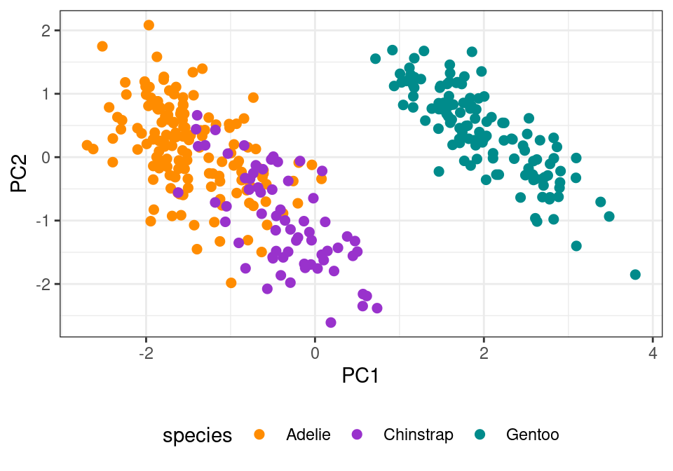

## Plotting PCA

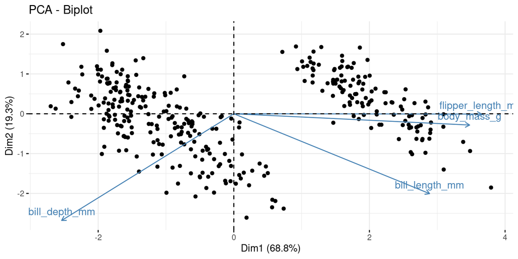

```r
library(factoextra)

penguins_pca %>% fviz_pca_biplot(label = "var")
```

## Summary

Principal Component Analysis

- Principal components
- `stats::prcomp`
- Interpretation

**Next**: Centroid-based clustering

- K-means
- Fuzzy c-means
- Geodemographic classification